# Introducción al problema del máximo flujo

Miguel Miní

28/6/2020

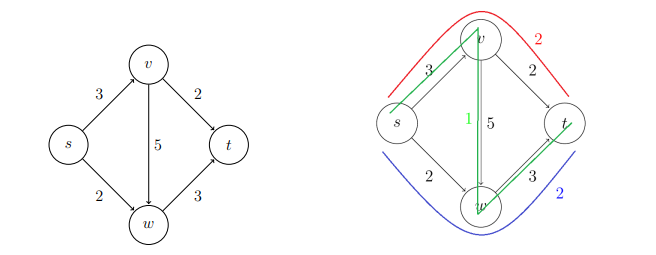

Figura 1. A nuestra izquierda nuestra primera red de flujo. A la derecha un ejemplo de un flujo de 5, donde los caminos rojo, verde y azul tienen un flujo de 2, 1, 2 respectivamente.

## Definición:

El problema del máximo flujo es un clásico fácil de usar / difícil de entender en el análisis de algoritmos. Por eso primero tendremos en consideración más informal que formal.

La figura 1(a) muestra una red de flujo, los valores de las aristas indican la máxima cantidad de “algo” que puede fluir sobre esas mismas. El objetivo es averiguar cuanto es la máxima cantidad de “algo” que puedo enviar desde el vértice s hacia el vértice t.

Por ejemplo, en la figura 1(b) exhibe un método de enviar 5 unidades de flujo desde s hacia t, mientras se respeta todas las capacidades de las aristas. puedo mejorar esta cantidad? No, podemos fijarnos que desde s, por sus dos aristas, solo puede fluir a lo más 5 de flujo.

Formalmente, un ejemplo del problema del máximo flujo es especificado por las siguientes propiedades:

1. Un grafo dirigido $G$, con $V$ vértices y aristas dirigidas $E$.
2. Un vértice fuente $s \in V$
3. Un vértice sumidero $t \in V$
4. Un entero no negativo $u_e$ por cada arista $e \in E$

Como el objetivo es enviar flujo desde s hacia t, nosotros podemos asumir sin perdida de generalidad que s no tiene aristas entrantes y t no tiene aristas de salida.

Formalmente, un flujo es un vector no negativo $\{f_e\} ~e \in E$, indexado por las aristas de F, que satisface dos restricciones:

- Restricciones de capacidad: $f_e \le u_e$ para toda $e \in E$
- Conversación de flujo: para todo vértice $v$ otro que $s$ y $t$,

monto de flujo entrando de $v$ $=$ monto de flujo saliendo de $v$

El lado izquierdo es la suma de los $f_e$ sobre todas las aristas entrando en $v$; simétricamente con el lado derecho. El objetivo es computar el máximo flujo, uno con el máximo posible valor, entendiendo este monto como el flujo que sale de s (el mismo que entra por t).

## Un algoritmo greedy ingenuo.

Ahora fijemonos en el diseño de un algoritmo eficiente para el problema del flujo máximo. A priori, no es claro que este algoritmo exista (Solo de lo que hemos visto, este puede ser un NP-hard).

Comenzaremos con un algoritmo greedy. El enfoque greedy para el máximo flujos es iniciar con todas las aristas con flujo **cero**, y greedimente producir flujos con mayor valor. El proceso natural es enviar flujos sucesivamente por caminos de $s$ hacia $t$.

```cpp
int greedy(graph G) {
  for (auto& e : G.E) { //asignar 0 a las aristas
    e.flow = 0;
  }
  int max_flow = 0;
  while (true) {
    //encontrar un path de s a t tal que e.capacity > e.flow,
    //bfs o dfs sirven.
    auto path = find_path(G, s, t);
    if (path.size() > 0) {
      auto delta = inf;
      for (auto e : path.E) { //hallar el maximo flujos que se puede enviar.
        delta = min(delta, e.capacity - e.flow);
      }
      for (auto& e : pathE) { //actualizar el flujo en las aristas.
        e.flow += delta;
      }
      maxflow += delta; //actualizar el flujo.
    } else {
      break; //no existe más paths.
    }
  }
  return max_flow;
}
```

Tenga en cuenta que pueden ser muchos caminos desde s hacia t, cualquiera es suficiente que cumpla e.capacity > e.flow. Luego de eso enviamos la mayor cantidad de flujo posible.

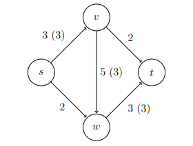

Figura 3: El algoritmo greedy no retorna un resultado óptimo si primero tomamos el camino s, v, w, t.

Este algoritmo es simple y natural, pero ¿funciona? esto significa, cuando termina con un flujo, ¿Es necesario que sea un flujo máximo? El ejemplo que tenemos dice que no (figura 3).

## Grafo Residual

Una segunda idea es *extender* el ingenuo algoritmo greedy permitiendo operaciones “regresar”. Por ejemplo, a pesar de que el algoritmo anterior no sea correco, nosotros podriamos enviar 2 unidades mas desde s hacia w, y luego regresar flujo por la arista $(v, w)$, regresando 2 de las 3 unidades que fueron enviadas en el paso anterior y finalmente a traves de la arista $(v, t)$. Esto nos permitirá tener un flujo de 5, que es máximo.

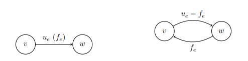

Figura 4. (a) arista original con capacidad y flujo (b) arista resultante en la red residual

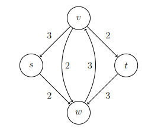

figura 5. Red de glujo residual en la figura 3

Debemos definir que significa permitir “regresar” operaciones. Esto motiva la siguiente simple pero importante definición, de una *red residual*. La idea es que, dado un grafo G y un flujo f en este, nosotros formamos una nueva red de flujo $G_f$ que tiene el mismo conjunto de vertices de G y que tiene dos aristas por cada arista de $G$. una arista $e = (v, w)$ de $G$ lleva flujo $f_e$ y tiene capacidad $u_e$ (Figura 4a.) se convierte en una “arista de avance” $(u, v)$ de $G_f$ con capacidad $u_e - f_e$ (lo que aun se puede enviar) y una “arista de regreso” $(w, v)$ de $G_f$ con capacidad $f_e$ (el monto del flujo enviado por esta arista, que puede ser regresado). Ver figura 4(b). Observe que una camino en la red $G$, es un caso especial de caminos en $G_f$ donde solo se consideran aristas de avance.

Por ejemplo, con $G$ de nuestro ejemplo y $f$ el flujo en la figura 3, la correspondiente red residual $G_f$ es vista en la figura 5. las 4 aristas con capacidad 0 en $G_f$ son omitidas en la imagen.

## El algoritmo de Ford-Fulkerson

Felizmente, si nosotros corremos el algoritmo greedy natural sobre la red residual, nosotros obtendremos un algoritmo correcto, el algoritmo de Ford-Fulkerson.

```cpp
int ford_fulkerson(graph G) {
  int max_flow = 0;
  for (auto& e : G.E) { //inicializar el flujo
    e.flow = 0;
  }
  auto G_f = G;
  while (true) {
    auto path = find_path(G_f, s, t); //encontrar cualquier camino
    //tal que las aristas cumplan e.capacity - e.flow
    if (path.size() > 0) {
      auto delta = inf;
      for (auto e : path) { //hallar el maximo flujo para aumentar
        delta = min(delta, e.capacity - e.flow);
      }
      for (auto& e : path) { //agregar flujo al camino
        e.flow += delta;
        reverse(Gf, e).flow -= delta; //y quitar a las aristas inversas
      }
    } else {
      break;
    }
  }
  return max_flow;
}
```

Por ejemplo, iniciando desde la red residual de la figura 5, el algoritmo de Ford-Fulkerson deberia aumentar el flujo a traves del camino s, w, v, t. Esto ultimo produce el maximo flujo esperado.

Nosotros ahora prestaremos atencion sobre la correctitud, la complejidad la veremos en la siguiente clase.

## El algoritmo termina

Nosotros afirmamos que el algoritmo de Ford-Fulkerson termina eventualmente con un flujo factible. esto es debido a dos invariantes, ambas probables por induccion sobre el número de iteraciones.

En primer lugar, el algoritmo mantiene la invariante que $\{f_e\}$ $e \in E$ es un flujo. Esto es claramente verdad al inicio. El parametro *delta* es definido tal que no exista valor $f_e$ que se vuelva negativo o exceda la capacidad $u_e$. Por el lado de conservacion de flujo, considera un vertice $v$, si $v$ no está en el path $P$ en $G_f$, entonces el flujo no varia trivialmente. Si $v$ pertenece a $P$. entonces, las aristas aunque seran de avance o de retroceso agregan y quitan el mismo valor en el grafo original. Por tanto el flujo es preservado.

La pregunta actual es… ¿El algoritmo en verdad termina con un flujo máximo?

## Afirmación (condición de optimalidad para el máximo flujo)

Si $f$ es un flujo en $G$ tal que la red residual $G_f$ no tiene caminos de $s$ hacia $t$, entonces $f$ es un flujo máximo.